# Tidyverse

Adam Rawles

### Background

- What is the tidyverse?
  - A series of packages created by Hadley Wickham
  - Used for data analysis and science
  - All based on an underlying philosophy and structure

### Packages

- tidyr*
- dplyr*
- stringr*
- ggplot2*
- tibble
- readr
- purrr
- forcats

### Tidy Data

- A format for datasets
  - Each variable in a column
  - Each observation on a row
  - Separate tables for different “types” of variables
  - Each related table has a linkable column
- Why use the tidy data format?
  - Easier plotting, analysis and manipulation
  - A common format for all datasets
  - Models can be easily translated from one dataset to another

### Tidy Data (example)

```
# A tibble: 3 x 4
  settlement_date  coal  wind solar
  <chr>           <dbl> <dbl> <dbl>
1 10 Jun 2018       240   120    90
2 11 Jun 2018       200   150   100
3 12 Jun 2018       190   125    85
```

```
# A tibble: 9 x 3
  settlement_date fuel_type output_mwh
  <chr>           <chr>          <dbl>
1 10 Jun 2018     coal             240
2 10 Jun 2018     wind             120
3 10 Jun 2018     solar             90
4 11 Jun 2018     coal             200
5 11 Jun 2018     wind             150
6 11 Jun 2018     solar            100
7 12 Jun 2018     coal             190
8 12 Jun 2018     wind             125
9 12 Jun 2018     solar             85
```

### tidyr

- A package to help with the “tidying” process
- Two main groups of functions:
  - Tidying (reshaping)
  - Value manipulation

### tidyr - Reshaping

- gather()
  - Use this function to convert multiple columns into a key and value column
- spread()
  - Use this function to convert a key column into multiple columns
  - Basically the opposite of gather()

### gather()

- gather()
  - Parameters:
    - data: the data frame
    - key: the name of the new “key” column
    - value: the name of the new “value” column
    - …: the columns to be converted

```
# A tibble: 3 x 4
  settlement_date  coal  wind solar
  <chr>           <dbl> <dbl> <dbl>
1 10 Jun 2018       240   120    90
2 11 Jun 2018       200   150   100
3 12 Jun 2018       190   125    85
```

### gather()

```r
untidy_data <- tribble(~settlement_date, ~coal, ~wind, ~solar,
                    "10 Jun 2018", 240, 120, 90,
                    "11 Jun 2018", 200, 150, 100,
                    "12 Jun 2018", 190, 125, 85)

tidy_data <- gather(untidy_data, key = "fuel_type", value = "output_mwh", coal:solar) #we could also use c(coal, wind, solar)

tidy_data
```

```
# A tibble: 9 x 3
  settlement_date fuel_type output_mwh
  <chr>           <chr>          <dbl>
1 10 Jun 2018     coal             240
2 11 Jun 2018     coal             200
3 12 Jun 2018     coal             190
4 10 Jun 2018     wind             120
5 11 Jun 2018     wind             150
6 12 Jun 2018     wind             125
7 10 Jun 2018     solar             90
8 11 Jun 2018     solar            100
9 12 Jun 2018     solar             85
```

### gather() - exercise

- Import the .csv file I sent you
- Convert it to the tidy data format

### tidyr - value manipulation

- You can also use tidyr to handle missing values, and split or concatenate cells
- Missing values
  - drop_na(data, …) removes all rows with NA in … columns
  - fill(data, …) replaces all NAs with most recent values in …columns
  - replace_na(data, replace, …) replaces all NAs with the values in replace in …columns
- Split/join
  - seperate/_rows(data, col, into, sep) separates values into several columns/rows
  - unite(data, col, …, sep) unites …columns into a single column with a separator

### tidyr - value manipulation example

```r
unite(untidy_data, coal, solar, wind, col = "coal_solar_wind", sep = "/",  )
```

```
# A tibble: 3 x 2
  settlement_date coal_solar_wind
  <chr>           <chr>
1 10 Jun 2018     240/90/120
2 11 Jun 2018     200/100/150
3 12 Jun 2018     190/85/125
```

### dplyr

- So now you've got your raw tidy data
- The next step is data manipulation
  - aggregate
  - calculated columns
  - subset
- All of these can be done with the dplyr package

### dplyr - the pipe %>%

- The pipe passes the evaluated result of a function on the left of the pipe as the first argument to the function on the right
- Example

```r
library(tidyverse)

sum(c(1,2,3,4)) %>% print()
```

```
[1] 10
```

```r
"hello" %>% substr(1,2)
```

```
[1] "he"
```

### dplyr - the pipe %>%

- This can be very useful when performing multiple manipulation steps
  - e.g. grouping, then finding an average, then subsetting, etc.
  - It also allows you to read from left to right, rather than from inside to outside if the function calls were embedded…

```r
sum(c(1,2,3,4)) %>% print()
```

```
[1] 10
```

```r
print(sum(c(1,2,3,4)))
```

```
[1] 10
```

### dplyr - the pipe %>%

- If you don't want the evaulated result to be passed as the first argument, you can use a full stop (“.”) to specify which parameter you want the result passed as…

```r
2 %>% substr("hello", ., 4)
```

```
[1] "ell"
```

### dplyr - aggregate

- summarise()
  - This is the main aggregation function
  - Parameters
    - .data: the data frame to be summarised
    - … name-value pairs of summary functions
      - This defines what type of summary we want to do

### dplyr - summarise() example

```r
output_data <- tibble::tribble(~settlement_date, ~fuel_type, ~output_mwh,
                "10 Jun 2018", "coal", 240,
                "10 Jun 2018", "wind", 120,
                "10 Jun 2018", "solar", 90,
                "11 Jun 2018", "coal", 200,
                "11 Jun 2018", "wind", 150,
                "11 Jun 2018", "solar", 100,
                "12 Jun 2018", "coal", 190,
                "12 Jun 2018", "wind", 125,
                "12 Jun 2018", "solar", 85)

output_data %>% summarise(output_mean = mean(output_mwh))
```

```
# A tibble: 1 x 1
  output_mean
        <dbl>
1        144.
```

### dplyr - summarise() by group

- Alone, this functionality isn't particularly powerful
- However, when you combine with the group_by() function, you can produce more useful summaries
- The group_by() function does exactly what it says: it groups the values based a key field

```r
output_data %>% group_by(settlement_date) %>% summarise(output_mean = mean(output_mwh))
```

```
# A tibble: 3 x 2
  settlement_date output_mean
  <chr>                 <dbl>
1 10 Jun 2018            150
2 11 Jun 2018            150
3 12 Jun 2018            133.
```

- This is similar to the aggregate functions and group by clauses in SQL

### dplyr - calculated columns

- Another feature of the dplyr package is the ability to produce calculated columns more easily
- The mutate() function does this for us

### dplyr - mutate()

- mutate()
  - Parameters
    - .data: the data frame to which the column will be added
    - …: name-value pairs of expressions. Name will be the column name and value will be the calculated value

### dplyr - mutate() example

```r
output_data %>% mutate(cum_output = cumsum(output_mwh))
```

```
# A tibble: 9 x 4
  settlement_date fuel_type output_mwh cum_output
  <chr>           <chr>          <dbl>      <dbl>
1 10 Jun 2018     coal             240        240
2 10 Jun 2018     wind             120        360
3 10 Jun 2018     solar             90        450
4 11 Jun 2018     coal             200        650
5 11 Jun 2018     wind             150        800
6 11 Jun 2018     solar            100        900
7 12 Jun 2018     coal             190       1090
8 12 Jun 2018     wind             125       1215
9 12 Jun 2018     solar             85       1300
```

### dplyr - mutate() example

- With a group_by() clause…

```r
output_data %>% group_by(fuel_type) %>% mutate(cum_output = cumsum(output_mwh))
```

```
# A tibble: 9 x 4
# Groups:   fuel_type [3]
  settlement_date fuel_type output_mwh cum_output
  <chr>           <chr>          <dbl>      <dbl>
1 10 Jun 2018     coal             240        240
2 10 Jun 2018     wind             120        120
3 10 Jun 2018     solar             90         90
4 11 Jun 2018     coal             200        440
5 11 Jun 2018     wind             150        270
6 11 Jun 2018     solar            100        190
7 12 Jun 2018     coal             190        630
8 12 Jun 2018     wind             125        395
9 12 Jun 2018     solar             85        275
```

### dplyr - exercise

- Using your tidied data set…
- Create a new column of the next value (lead()), grouped by fuel type
- Summarise the dataset (your choice of function) by settlement date

### stringr

- We won't go into much detail here today
- stringr is a package for string manipulation
- It uses the regex language (which stands for regular expression) in its functions
  - This language allows us to search for very specific character patterns
- TL;DR Use this package if you ever need to search for text or for an expression

### ggplot2

- ggplot2 is a powerful graphing package
- It's based on a philosophy called The Grammar of Graphics
  - A plot is made up of a number of parts
    - The data, and its mapping to the plot area (which data goes on the X and which data goes on the Y)
    - Geometric objects (do we want to use lines, or bars, or points, or whatever)
    - The scales, titles, legends, etc (often collectively termed “scale”)
  - The data and the geometric objects together form a layer, and a plot can have many layers

### ggplot2 - layer

- To create a layer, we need a data set, our mappings, and our objects
- To do this, we employ ggplot2's hierarchical structure
- First, we start with the ggplot() function where we define our dataset and optionally your aesthetics…

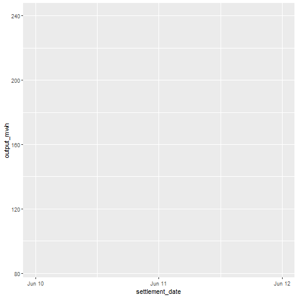

```r
ggplot(data = output_data, aes(x = settlement_date, y = output_mwh))
```

### ggplot2 - layer

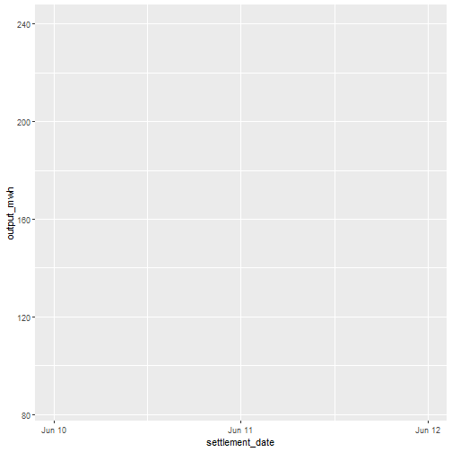

```r
ggplot(data = output_data, aes(x = settlement_date, y = output_mwh))
```

- Here, we've defined our data set and our aesthetics (our mappings), but no geometric object
- From this, we could create any type of graph we want

### ggplot2 - layer

- To add a geometric object, we use the appropriate geom_x function for the plot we want…

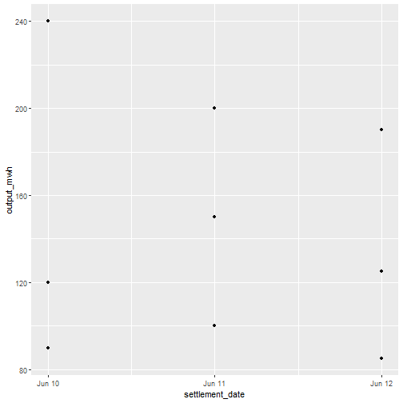

```r
ggplot(data = output_data, aes(x = settlement_date, y = output_mwh)) + geom_point()
```

- The geom_point function inherits from our ggplot call, so it knows what dataset and X and Y values we want
- And that's a layer completed

### ggplot - structure

- In the previous example, we only had 1 layer
- In some cases however, you may want many layers with different aesthetic mappings (particularly if you're grouping)
- By default, each geometric object function inherits the parameters of our ggplot call, but you can define additional aesthetics very easily…

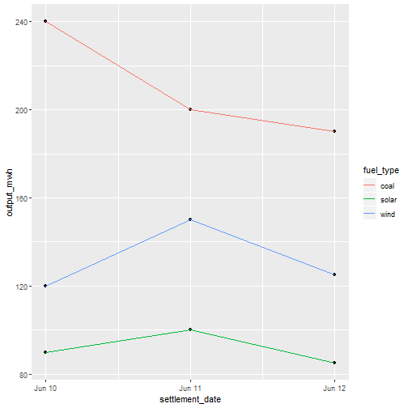

```r
ggplot(data = output_data, aes(x = settlement_date, y = output_mwh)) + geom_point() + geom_line(aes(color = fuel_type))
```

### ggplot - structure

- Because of how inheritance works in ggplot2, we could produce exactly the same graph with…

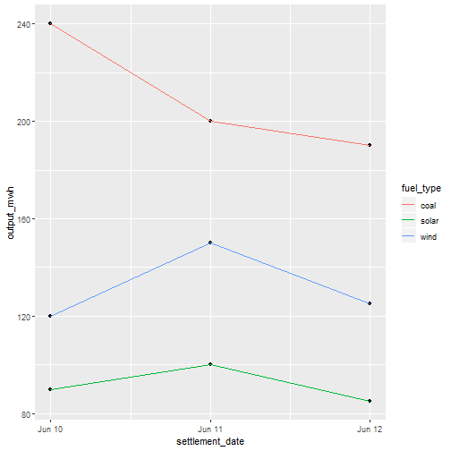

```r
ggplot(data = output_data) + geom_point(aes(x = settlement_date, y = output_mwh)) + geom_line(aes(x = settlement_date, y = output_mwh, color = fuel_type))
```

- But clearly one is easier to read than the other…

### ggplot2 - structure

- ggplot2 separates out the values and the type of plot you're producing (the geometric object)
- This means you can easily change the look of your graph without changing the underlying data
- However, some geometric objects can only accept certain aesthetic mappings…

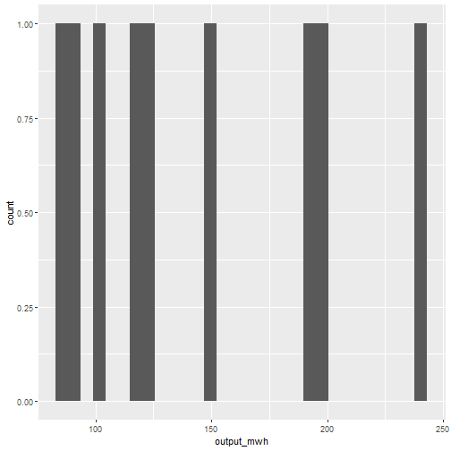

```r
ggplot(data = output_data) + geom_histogram(aes(x = output_mwh))
```

- There's no Y value for a histogram, so supplying one would give an error

### ggplot2 - exercise

- Using your tidy data, produce a plot including a grouping variable

### ggplot2 - scales

- The default scales in ggplot2 are usually pretty good
- However, there will always be aspects that you want to change
- To change a scale, we use the scale_x_datatype functions…

```r
... + scale_x_continuous()
... + scale_x_date()
... + scale_x_discrete()
```

### ggplot2 - scales

- Each of these scale_x_datatype function accept slightly different parameters, but there are some common ones…
  - name; character string with the scale title
  - breaks; a vector of the scale breaks
  - labels; a vector of character strings the same length as breaks
  - limits; a two value numeric vector
  - expand; a two value numeric vector

### ggplot2 - exercise

- Change some aspect(s) of both of the scales on your plot

### ggplot2 - themes

- In ggplot2, we can add themes to our plots
- This changes some of the less important graphical features of the graph
  - the plotting background color
  - the font
  - the gridlines
  - the text rotation
  - the text size
- Currently, I've got a theme_elexon(), but it needs some improvement so suggestions are welcome

### Conclusion

- The tidyverse is a collection of packages to help with data manipulation
- Use tidyr for cleaning, dplyr for manipulation, and ggplot2 for plotting
- All packages use a common philosophy, pioneered by Hadley Wickham
- All packages are open source, and very well documented on Github